# Assignment 2: Differential Gene expression and Preliminary ORA

Advait Sridhar

2022-03-19

# Brief Introduction

The objective of this report is to perform differential gene expression analysis and preliminary thresholded over-representation analysis on a chosen Bulk RNA-seq dataset, which can be found here: https://www.ncbi.nlm.nih.gov/geo/query/acc.cgi?acc=GSE173940. The initial processing was done in the first assignment, where the count file was downloaded through Bioconductor using GEO id GSE173940. Data was filtered by only keeping rows with significant counts. The rows had ensembl gene ids, which were mapped to HUGO gene symbols using biomaRt. Data was cleaned as the rows which contained pseudogenes or no conversion to HUGO symbols were removed, and rows with duplicate ensembl gene ids were removed as well. Data was normalized by calculating normalization factors using edgeR package and applying these to the dataset. Normalization was checked using boxplot, density plot, MDS plot, BCV plot, and mean-var plot. These filtered, normalized, and cleaned data was downloaded in a txt file which can be found in “A2_data”. This data will be used for this report to calculate differential expression in various samples as well as conduct preliminary ORA.

```r
#Setting Working Directory
setwd("/home/rstudio/projects")
getwd()
```

```
## [1] "/home/rstudio/projects"
```

```r
#Installing and Loading Required Packages
if (!requireNamespace("BiocManager", quietly = TRUE))
    install.packages("BiocManager")
if (!requireNamespace("knitr", quietly = TRUE))
    install.packages("knitr")
if (!requireNamespace("Biobase", quietly = TRUE))
    BiocManager::install("Biobase")
if (!requireNamespace("limma", quietly = TRUE))
    install.packages("limma")
if (!requireNamespace("ComplexHeatmap", quietly = TRUE))
    BiocManager::install("ComplexHeatmap")
if (!requireNamespace("circlize", quietly = TRUE))
    install.packages("circlize")
if (!requireNamespace("gprofiler2", quietly = TRUE))
    install.packages("gprofiler2")

library(BiocManager)
library(knitr)
library(Biobase)
library(limma)
library(ComplexHeatmap)
library(circlize)
library(gprofiler2)
```

Downloading the Data

```r
#Reading filtered normalized cleaned data from txt file
atm_count_data <- read.table(file=file.path(getwd(), "A2_data",
                              "atm_exp_filtered_norm_clean.txt"),
                                    header = TRUE,sep = "\t",
                                    stringsAsFactors = FALSE,
                                    check.names=FALSE)

kable(atm_count_data[1:5,1:5], type="html")
```

| ensembl_id | hgnc_symbol | Wouter1 | Wouter2 | Wouter3 |
| --- | --- | --- | --- | --- |
| ENSG00000000003 | TSPAN6 | 191 | 91 | 217 |
| ENSG00000000005 | TNMD | 0 | 0 | 0 |
| ENSG00000000419 | DPM1 | 82 | 60 | 98 |
| ENSG00000000457 | SCYL3 | 12 | 7 | 17 |
| ENSG00000000460 | C1orf112 | 26 | 18 | 33 |

Creating Samples Dataframe

```r
#creating list of treatments that weren't included in original data
treatment <- c("WT", "Camptothecin", "DMSO", "Camptothecin", "DMSO", "Camptothecin", "DMSO", "Camptothecin", "ATM-KO", "WT", "ATM-KO", "WT", "ATM-KO", "WT", "ATM-KO", "DMSO", "ATM-KO", "ATM-KO", "ATM-KO", "ATM-KO", "DMSO", "DMSO", "DMSO", "DMSO", "Camptothecin", "Camptothecin", "Camptothecin", "Camptothecin", "DMSO", "DMSO", "DMSO", "DMSO")

#creating list of cell lines used for experimentation
cell_line <- c("U2OS", "HEK293T", "HEK293T", "HEK293T", "HEK293T", "HEK293T", "HEK293T", "HEK293T", "U2OS", "U2OS", "U2OS", "U2OS", "U2OS", "U2OS", "U2OS", "HEK293T", "HEK293T", "HEK293T", "HEK293T", "HEK293T", "HEK293T", "HEK293T", "HEK293T", "HEK293T", "U2OS", "U2OS", "U2OS", "U2OS", "U2OS", "U2OS", "U2OS", "U2OS")

#compiling cell lines and treatment information into a data frame
samples <- data.frame(cell_line, treatment)

#changing rownames to sample names in count data
rownames(samples) <- colnames(atm_count_data[,3:ncol(atm_count_data)])

#creating new sample names with information of patient number, cell line, and treatment group
samples$sample_name <- paste(as.numeric(gsub("Wouter", "", rownames(samples))), samples$cell_line, samples$treatment, sep = "_")

samples[1:5,]
```

|  | cell_line | treatment | sample_name |
| --- | --- | --- | --- |
| Wouter1 | U2OS | WT | 1_U2OS_WT |
| Wouter2 | HEK293T | Camptothecin | 2_HEK293T_Camptothecin |
| Wouter3 | HEK293T | DMSO | 3_HEK293T_DMSO |
| Wouter4 | HEK293T | Camptothecin | 4_HEK293T_Camptothecin |
| Wouter5 | HEK293T | DMSO | 5_HEK293T_DMSO |

# Differential Gene Expression

The aim of this report is to perform differential gene expression analysis using the normalized counts file. We can do this by firstly creating an expression matrix dataset containing count data prior to analysis within their respective samples. (Isserlin, 2022)

```r
#Creating an expression matrix to analyze differential expression between genes
expression_matrix <- as.matrix(atm_count_data[,3:34])

#Changing rownames to ensembl ids for accurate mapping
rownames(expression_matrix) <- atm_count_data$ensembl_id

#Changing column names to combined sample names
colnames(expression_matrix) <- colnames(atm_count_data)[3:34]

#Creating minimal set using expression matrix
minimal_set <- ExpressionSet(assayData = expression_matrix)
```

Initial model design only takes into account the treatment for each sample, of which there are 4 treatments for 32 samples. The matrix model below reflects this.

```r
atm_model_design <- model.matrix(~ samples$treatment )

kable(atm_model_design[1:5,], type="html")
```

[output not shown]

Using this initial model, we can create a linear model using the treatments with their respective samples and counts to create a MArrayLM object. Empirical Bayes was applied to this object to get preliminary stats on differential expression for each gene in the cleaned dataset. The gene names were combined with these statistics and the output can be viewed below. (Isserlin, 2022)

```r
#Linear Model using minimal set and model with cell lines and treatments
atm_fit <- lmFit(minimal_set, atm_model_design)

#Empirical Bayes for computing stats of linear model
atm_fit2 <- eBayes(atm_fit,trend=TRUE)

#Creating table with stats of differential expression for each gene and associated p values
atm_topfit <- topTable(atm_fit2, coef=ncol(atm_model_design), adjust.method = "none", number = nrow(expression_matrix))

#Merging HUGO gene symbols with data
atm_output_hits <- merge(atm_count_data[,1:2], atm_topfit,by.y=0,by.x=1,all.y=TRUE)

#Sorting by p value in ascending order
atm_output_hits <- atm_output_hits[order(atm_output_hits$P.Value),]

kable(atm_output_hits[1:10,1:8],type="html",row.names = FALSE)
```

| ensembl_id | hgnc_symbol | logFC | AveExpr | t | P.Value | adj.P.Val | B |
| --- | --- | --- | --- | --- | --- | --- | --- |
| ENSG00000239523 | MYLK-AS1 | 9.625 | 5.00000 | 5.006062 | 0.0000222 | 0.0000222 | -4.504088 |
| ENSG00000253898 | LINC01419 | 107.125 | 29.43750 | 4.496593 | 0.0000940 | 0.0000940 | -4.515478 |
| ENSG00000248498 | ASNSP1 | 69.625 | 21.46875 | 4.329255 | 0.0001504 | 0.0001504 | -4.519398 |
| ENSG00000219747 | RPL32P16 | 9.125 | 5.18750 | 4.073098 | 0.0003071 | 0.0003071 | -4.525550 |
| ENSG00000180113 | TDRD6 | -6.375 | 3.62500 | -4.029832 | 0.0003461 | 0.0003461 | -4.526606 |
| ENSG00000103257 | SLC7A5 | 373.500 | 363.56250 | 4.003265 | 0.0003725 | 0.0003725 | -4.527257 |
| ENSG00000172216 | CEBPB | 252.375 | 232.56250 | 3.997770 | 0.0003782 | 0.0003782 | -4.527391 |
| ENSG00000133027 | PEMT | 126.500 | 90.65625 | 3.953624 | 0.0004271 | 0.0004271 | -4.528476 |
| ENSG00000258315 | C17orf49 | 16.500 | 11.78125 | 3.896880 | 0.0004992 | 0.0004992 | -4.529877 |
| ENSG00000101255 | TRIB3 | 62.625 | 31.43750 | 3.843044 | 0.0005785 | 0.0005785 | -4.531212 |

The number of genes with significant differential expression was calculated and ended up to be 1364 prior to correction. Threshold was set at p < 0.05 as this is a standard for differential expression data and was used by the researchers in their paper, albeit arbitrarily.

```r
#Number of genes with significant differential expression
length(which(atm_output_hits$P.Value < 0.05))
```

```
## [1] 1364
```

```r
#Designing model using matrix of sample cell lines and respective treatments
atm_model_design_corrected <- model.matrix( ~ samples$cell_line + samples$treatment)

kable(atm_model_design_corrected[1:5,1:5],type="html")
```

[output not shown]

Another linear model was used to analyze the relatedness of the gene counts to the corrected model. Empirical Bayes was applied to this object to get preliminary stats on differential expression for each gene in the cleaned dataset. Multiple hypothesis testing was done using the bonferroni correction, which was used by the researchers in the original paper to perform all possible pairs of comparisons (Huiting et al, 2021). The gene names were combined with these statistics and the output can be viewed below.

```r
#Linear Model using minimal set and model with cell lines and treatments
atm_fit_corrected <- lmFit(minimal_set, atm_model_design_corrected)

#Empirical Bayes for computing stats of linear model
atm_fit2_corrected <- eBayes(atm_fit_corrected,trend=TRUE)

#Creating table with stats of differential expression for each gene and associated p values
atm_topfit_corrected <- topTable(atm_fit2_corrected, coef=ncol(atm_model_design_corrected), adjust.method = "bonferroni", number = nrow(expression_matrix))

#Merging HUGO gene symbols with data
atm_output_hits_corrected <- merge(atm_count_data[,1:2], atm_topfit_corrected,by.y=0,by.x=1,all.y=TRUE)

#Sorting by p value in ascending order
atm_output_hits_corrected <- atm_output_hits_corrected[order(atm_output_hits_corrected$P.Value),]

kable(atm_output_hits_corrected[1:10,1:8],type="html",row.names = FALSE)
```

| ensembl_id | hgnc_symbol | logFC | AveExpr | t | P.Value | adj.P.Val | B |
| --- | --- | --- | --- | --- | --- | --- | --- |
| ENSG00000183091 | NEB | -11.8250 | 6.31250 | -4.807990 | 0.0000420 | 0.6159010 | -4.514307 |
| ENSG00000169435 | RASSF6 | -24.4250 | 15.00000 | -4.728049 | 0.0000525 | 0.7698563 | -4.515948 |
| ENSG00000239523 | MYLK-AS1 | 9.6500 | 5.00000 | 4.720214 | 0.0000537 | 0.7868683 | -4.516110 |
| ENSG00000253898 | LINC01419 | 115.8625 | 29.43750 | 4.666575 | 0.0000624 | 0.9138033 | -4.517223 |
| ENSG00000120254 | MTHFD1L | 181.6750 | 139.34375 | 4.665692 | 0.0000625 | 0.9160562 | -4.517241 |
| ENSG00000172216 | CEBPB | 291.6875 | 232.56250 | 4.641785 | 0.0000668 | 0.9791587 | -4.517741 |
| ENSG00000248498 | ASNSP1 | 76.7625 | 21.46875 | 4.630170 | 0.0000690 | 1.0000000 | -4.517984 |
| ENSG00000135111 | TBX3 | -436.5000 | 596.68750 | -4.609274 | 0.0000732 | 1.0000000 | -4.518422 |
| ENSG00000168298 | H1-4 | 163.2875 | 119.12500 | 4.485996 | 0.0001031 | 1.0000000 | -4.521036 |
| ENSG00000151012 | SLC7A11 | 802.1625 | 512.34375 | 4.418904 | 0.0001241 | 1.0000000 | -4.522478 |

The number of genes after model correction which were significantly expressed was 2017 using threshold p < 0.05.

```r
#Number of genes with significant differential expression
length(which(atm_output_hits_corrected$P.Value < 0.05))
```

```
## [1] 2017
```

The number of corrected genes were greater than those that were significantly expressed prior to correction, so the genes of interest lie in their commonly significantly expressed genes. This was investigated through plotting genes based on their p-value in both models, and finding the intersecting region that would lead to significantly expressed genes that we are interested in. The list of genes in each model and their associated p values were combined into a dataframe, and these 2 dataframes were merged to investigate each gene based on its p-value in both models. Colors were used to express the various groups in the plot: the genes that had no significant expression in either model were black, genes with significant expression only in the initial model were orange, genes with significant expression in the corrected model were blue, and genes with significant expression in both models were red. (Isserlin, 2022)

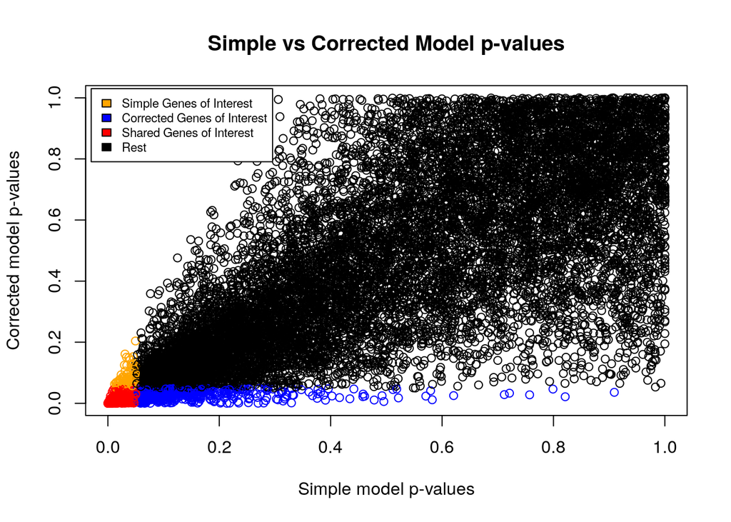

```r
#Creating dataframes with gene ids and p values from 2 models
atm_model_pvalues <- data.frame(ensembl_id = atm_output_hits$hgnc_symbol, atm_pvalue=atm_output_hits$P.Value)
atm_model_pvalues_corrected <-  data.frame(ensembl_id = atm_output_hits_corrected$hgnc_symbol,
                                           atm_pvalue_corrected = atm_output_hits_corrected$P.Value)

#Merging values from both models and assigning color based on significant p values
two_models_pvalues <- merge(atm_model_pvalues, atm_model_pvalues_corrected,by.x=1,by.y=1)
two_models_pvalues$colour <- "black"
two_models_pvalues$colour[two_models_pvalues$atm_pvalue<0.05] <- "orange"
two_models_pvalues$colour[two_models_pvalues$atm_pvalue_corrected<0.05] <- "blue"
two_models_pvalues$colour[two_models_pvalues$atm_pvalue<0.05 & two_models_pvalues$atm_pvalue_corrected<0.05] <- "red"

#Plotting both models p values against each other
plot(two_models_pvalues$atm_pvalue,
     two_models_pvalues$atm_pvalue_corrected,
     col = two_models_pvalues$colour,
     xlab = "Simple model p-values",
     ylab ="Corrected model p-values",
     main="Simple vs Corrected Model p-values")

legend(-0.03,1.03,legend=c("Simple Genes of Interest","Corrected Genes of Interest", "Shared Genes of Interest", "Rest"),
       fill=c("orange","blue", "red", "black"),cex = 0.7)
```

The merged dataframe was used to discern which genes were significantly expressed in both models, which are our genes of interest. This list of genes were inputted into a variable atm_top_hits, which was then used for visualization in a Volcano plot. Following the principle in the previous plot, 2 dataframes containing the logFC values and the negative log of the p values were merged with the gene names. The corrected model was used for this as it contained more genes that were differentially expressed, and so our genes of interest would be highlighted with greater contrast. The merged dataframe were queried with the list of genes of interest, which were plotted in red against the insignificantly expressed genes which were taken from the initial data. Data was highly spread out, so x-axis scale was set to (-50,50) for clearer visualization.

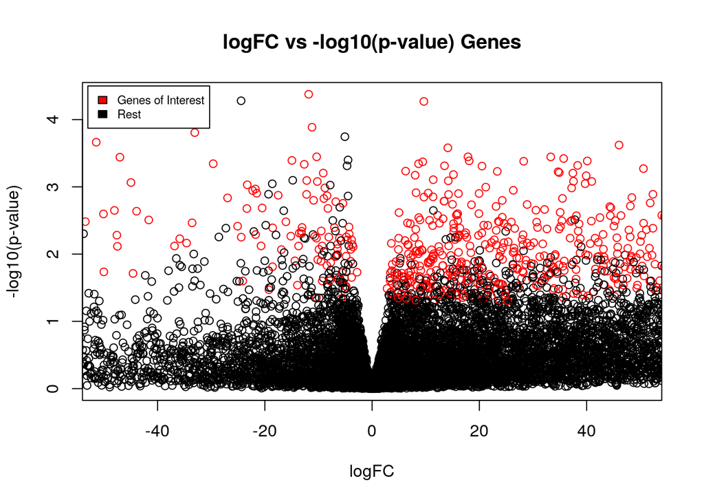

```r
#Creating list of genes of interest
atm_top_hits <- two_models_pvalues$ensembl_id[two_models_pvalues$colour == "red"]

#Creating 2 dataframes with logFC and -log(pvalue) from corrected output hits
atm_model_logFC <- data.frame(ensembl_id = atm_output_hits_corrected$hgnc_symbol, atm_model_logFC=atm_output_hits_corrected$logFC)
atm_model_nlog_pvalues <-  data.frame(ensembl_id = atm_output_hits_corrected$hgnc_symbol,
                                           atm_model_nlog_pvalues = -log10(atm_output_hits_corrected$P.Value))

#Merging dataframes and assigning color based on presence of genes of interest
two_models_volcano <- merge(atm_model_logFC, atm_model_nlog_pvalues,by.x=1,by.y=1)
two_models_volcano$colour <- "black"
two_models_volcano$colour[two_models_volcano$ensembl_id %in% atm_top_hits] <- "red"

#Creating Volcano plot
plot(two_models_volcano$atm_model_logFC,
     two_models_volcano$atm_model_nlog_pvalues,
     col = two_models_volcano$colour,
     xlab = "logFC",
     ylab ="-log10(p-value)",
     xlim = c(-50,50),
     main="logFC vs -log10(p-value) Genes")

legend(-53,4.5, legend=c("Genes of Interest", "Rest"), fill=c("red", "black"), cex = 0.7)
```

The number of genes that were differentially expressed in both models were combined into a variable with size 1234. These are the number of significantly differentially expressed genes after correction and plotting, which is lower than found in either model and constitute the genes of interest for further analysis.

```r
#Number of significantly differentially expressed genes from both models
length(atm_top_hits)
```

```
## [1] 1234
```

The top hits from our models were used to generate a heatmap to analyze how differential gene expression varied across samples. An initial heatmap matrix was created to include only the count data, with rownames being the specific ensembl gene ids and the column names being the detailed sample name with information about the patient number, cell line and treatment.

```r
#creating heatmap matrix with count data excluding gene ids
atm_heatmap_matrix <- atm_count_data[,3:ncol(atm_count_data)]

#renaming rows to ensembl ids
rownames(atm_heatmap_matrix) <- atm_count_data$ensembl_id

#using combined sample names for each column
colnames(atm_heatmap_matrix) <- samples$sample_name
```

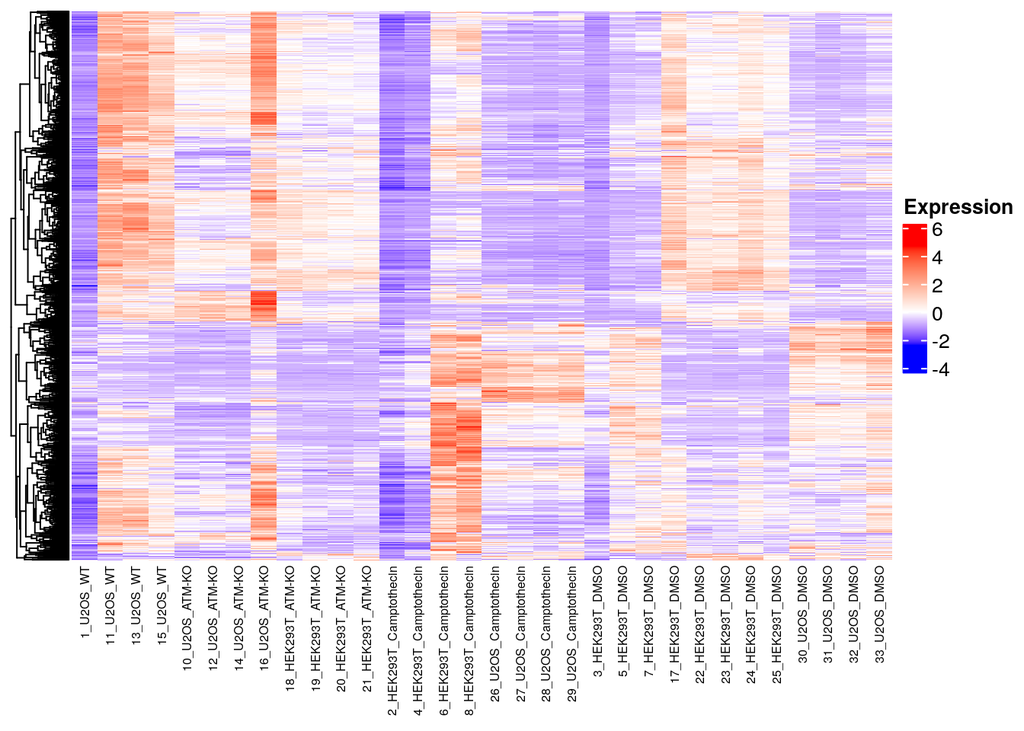

```r
#Creating scaled matrix with count data
atm_heatmap_matrix_scaled <- t(scale(t(atm_heatmap_matrix)))

#Querying matrix with list of genes of interest
atm_heatmap_matrix_tophits <- t(scale(t(atm_heatmap_matrix_scaled[which((two_models_pvalues$ensembl_id) %in% atm_top_hits),])))

#Ordering matrix by treatment group
atm_heatmap_matrix_tophits<- atm_heatmap_matrix_tophits[ ,
      c(grep(colnames(atm_heatmap_matrix_tophits),
                          pattern = "\\_WT"),
      grep(colnames(atm_heatmap_matrix_tophits),
                          pattern = "\\ATM-KO"),
       grep(colnames(atm_heatmap_matrix_tophits),
                          pattern = "\\Camptothecin"),
       grep(colnames(atm_heatmap_matrix_tophits),
                          pattern = "\\DMSO"))]

#Assigning colors based on relative expression values
if(min(atm_heatmap_matrix_tophits) == 0){
    atm_heatmap_col <- colorRamp2(c( 0, max(atm_heatmap_matrix_tophits)),
                             c( "white", "red"))
  } else {
    atm_heatmap_col <- colorRamp2(c(min(atm_heatmap_matrix_tophits), 0,
                    max(atm_heatmap_matrix_tophits)),
                    c("blue", "white", "red"))
  }

#Creating heatmap
atm_heatmap <- Heatmap(as.matrix(atm_heatmap_matrix_tophits),
                           cluster_rows = TRUE,
                           cluster_columns = FALSE,
                               show_row_dend = TRUE,
                               show_column_dend = FALSE,
                               col=atm_heatmap_col,
                               show_column_names = TRUE,
                               show_row_names = FALSE,
                               show_heatmap_legend = TRUE,
                               column_names_gp = gpar(fontsize = 6),
                               heatmap_legend_param = list(title = "Expression"),
                               name = "Heatmap"
                               )

atm_heatmap
```

# Thresholded over-representation analysis

After conducting some tests to analyze differential expression for our given set of genes, we need to query our up- and down- regulated genes against some annotation databases to discern the nature of the genes being selected for across samples in this experiment. First, this involved generating a corrected top hits data frame which included eBayes statistics for our list of genes of interest. A new column for rank, which is the approximate value obtained from the volcano plot, was included and the dataframe was ordered by the value of this column. Lists of upregulated and downregulated genes were created by selecting for genes that had positive logFC values (upregulated) or negative logFC values (downregulated) since all the genes in the list already have a p-value less than 0.05. The lists for upregulated, downregulated, and ranked sets of genes were all written into txt files which can be found in A2_data.

```r
#Merging dataframe with HUGO gene symbols in list of genes of interest
atm_top_hits_corrected <- atm_output_hits_corrected[atm_output_hits_corrected$hgnc_symbol %in% atm_top_hits,]

#Ordering by rank based on -log(pvalue) and logFC value
atm_top_hits_corrected[,"rank"] <- -log(atm_top_hits_corrected$P.Value, base = 10) * sign(atm_top_hits_corrected$logFC)

atm_top_hits_corrected <- atm_top_hits_corrected[order(atm_top_hits_corrected$rank),]

atm_ranked_genes <- data.frame(genename = atm_top_hits_corrected$hgnc_symbol, F_stat = atm_top_hits_corrected$rank)
atm_ranked_genes <- atm_ranked_genes[order(atm_ranked_genes$F_stat, decreasing = TRUE),]

#Creating lists of upregulated and downregulated genes based on logFC values (p < 0.05)
atm_upregulated_genes <- atm_top_hits_corrected$hgnc_symbol[which(atm_top_hits_corrected$logFC > 0)]

atm_downregulated_genes <- atm_top_hits_corrected$hgnc_symbol[which(atm_top_hits_corrected$logFC < 0)]

#Writing txt files for lists of upregulated, downregulated, and ranked genes
write.table(atm_upregulated_genes,
            file=file.path("A2_data","atm_upregulated_genes.txt"),sep = "\t",
            row.names = FALSE,col.names = FALSE,quote = FALSE)

write.table(atm_downregulated_genes,
            file=file.path("A2_data","atm_downregulated_genes.txt"),sep = "\t",
            row.names = FALSE,col.names = FALSE,quote = FALSE)

write.table(atm_ranked_genes,
            file=file.path("A2_data","atm_ranked_genes.txt"),sep = "\t",
            row.names = FALSE,col.names = FALSE,quote = FALSE)
```

Geneset enrichment analysis was performed using the gprofiler2 package, which queries g:profiler and associated annotation databases to see how many hits are returned for a queried gene (Kolberg et al, 2020). This method uses the fisher’s exact test, which is a gene list enrichment analysis strategy that is useful for our case since the ranked gene list was not used for this part of the analysis and we just used a threshold of p < 0.05 (Isserlin, 2022). Genes were queried against the “hsapiens” annotation database with gprofiler version e105_eg52_p16_e84549f. Information about the relevant annotation databases can be found below.

```r
get_version_info(organism = "hsapiens")
```

```
## $biomart
## [1] "Ensembl"
##
## $biomart_version
## [1] "105"
##
## $display_name
## [1] "Human"
##
## $genebuild
## [1] "GRCh38.p13"
##
## $gprofiler_version
## [1] "e105_eg52_p16_e84549f"
##
## $organism
## [1] "hsapiens"
##
## $sources
## $sources$CORUM
## $sources$CORUM$name
## [1] "CORUM protein complexes"
##
## $sources$CORUM$version
## [1] "03.09.2018 Corum 3.0"
##
##
## $sources$`GO:BP`
## $sources$`GO:BP`$name
## [1] "biological process"
##
## $sources$`GO:BP`$version
## [1] "annotations: BioMart\nclasses: releases/2021-12-15"
##
##
## $sources$`GO:CC`
## $sources$`GO:CC`$name
## [1] "cellular component"
##
## $sources$`GO:CC`$version
```

[output cut: 55 more lines]

```
## $sources$TF$version
## [1] "annotations: TRANSFAC Release 2021.3\nclasses: v2"
##
##
## $sources$WP
## $sources$WP$name
## [1] "WikiPathways"
##
## $sources$WP$version
## [1] "20211210"
##
##
##
## $taxonomy_id
## [1] "9606"
```

Gene list enrichment analysis was done for all the top hits together, the upregulated genes, and then the downregulated genes. A table with the queried genes and their respective term names was generated, as well as a plot to show the hits with their associated annotation databases on a background of all annotated genes. Custom background with genes only from our experiment was not used due to poor output for downregulated genes. The results from each query and their respective outputs can be seen below.

```r
atm_gost <- gost(query = atm_top_hits, organism = "hsapiens")
atm_gost$result$query <- "Top Hits from Query of Genes of Interest"
head(atm_gost$result)
```

|  | query | significant | p_value | term_size | query_size | intersection_size | precision | recall | term_id | source | term_name | effective_domain_size | source_order | parents |
| --- | --- | --- | --- | --- | --- | --- | --- | --- | --- | --- | --- | --- | --- | --- |
| 1 | Top Hits from Query of Genes of Interest | TRUE | 9.070509e-30 | 80 | 333 | 49 | 0.14714715 | 0.6125000 | CORUM:306 | CORUM | Ribosome, cytoplasmic | 3627 | 183 |  |
| 2 | Top Hits from Query of Genes of Interest | TRUE | 1.138505e-23 | 104 | 333 | 50 | 0.15015015 | 0.4807692 | CORUM:3055 | CORUM | Nop56p-associated pre-rRNA complex | 3627 | 1362 |  |
| 3 | Top Hits from Query of Genes of Interest | TRUE | 6.674367e-16 | 47 | 333 | 28 | 0.08408408 | 0.5957447 | CORUM:308 | CORUM | 60S ribosomal subunit, cytoplasmic | 3627 | 184 |  |
| 4 | Top Hits from Query of Genes of Interest | TRUE | 2.665950e-13 | 31 | 333 | 21 | 0.06306306 | 0.6774194 | CORUM:338 | CORUM | 40S ribosomal subunit, cytoplasmic | 3627 | 199 |  |
| 5 | Top Hits from Query of Genes of Interest | TRUE | 1.794781e-12 | 33 | 333 | 21 | 0.06306306 | 0.6363636 | CORUM:305 | CORUM | 40S ribosomal subunit, cytoplasmic | 3627 | 182 |  |
| 6 | Top Hits from Query of Genes of Interest | TRUE | 1.310653e-09 | 78 | 333 | 29 | 0.08708709 | 0.3717949 | CORUM:320 | CORUM | 55S ribosome, mitochondrial | 3627 | 191 |  |

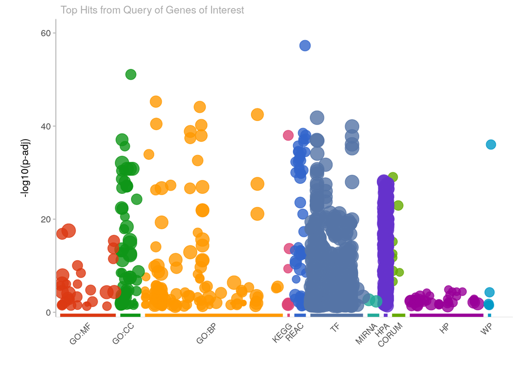

```r
gostplot(atm_gost, capped = FALSE, interactive = FALSE)
```

```r
atm_gost_up <- gost(query = atm_upregulated_genes, organism = "hsapiens")
atm_gost_up$result$query <- "Top Hits from Query of Upregulated Genes"
head(atm_gost_up$result)
```

|  | query | significant | p_value | term_size | query_size | intersection_size | precision | recall | term_id | source | term_name | effective_domain_size | source_order | parents |
| --- | --- | --- | --- | --- | --- | --- | --- | --- | --- | --- | --- | --- | --- | --- |
| 1 | Top Hits from Query of Upregulated Genes | TRUE | 1.675408e-30 | 80 | 321 | 49 | 0.15264798 | 0.6125000 | CORUM:306 | CORUM | Ribosome, cytoplasmic | 3627 | 183 |  |
| 2 | Top Hits from Query of Upregulated Genes | TRUE | 2.187662e-24 | 104 | 321 | 50 | 0.15576324 | 0.4807692 | CORUM:3055 | CORUM | Nop56p-associated pre-rRNA complex | 3627 | 1362 |  |
| 3 | Top Hits from Query of Upregulated Genes | TRUE | 2.822612e-16 | 47 | 321 | 28 | 0.08722741 | 0.5957447 | CORUM:308 | CORUM | 60S ribosomal subunit, cytoplasmic | 3627 | 184 |  |
| 4 | Top Hits from Query of Upregulated Genes | TRUE | 1.440858e-13 | 31 | 321 | 21 | 0.06542056 | 0.6774194 | CORUM:338 | CORUM | 40S ribosomal subunit, cytoplasmic | 3627 | 199 |  |
| 5 | Top Hits from Query of Upregulated Genes | TRUE | 9.767394e-13 | 33 | 321 | 21 | 0.06542056 | 0.6363636 | CORUM:305 | CORUM | 40S ribosomal subunit, cytoplasmic | 3627 | 182 |  |
| 6 | Top Hits from Query of Upregulated Genes | TRUE | 5.916508e-10 | 78 | 321 | 29 | 0.09034268 | 0.3717949 | CORUM:320 | CORUM | 55S ribosome, mitochondrial | 3627 | 191 |  |

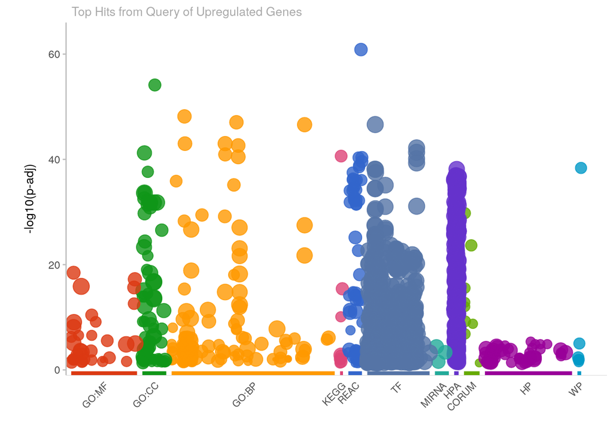

```r
gostplot(atm_gost_up, capped = FALSE, interactive = FALSE)
```

```r
atm_gost_down <- gost(query = atm_downregulated_genes, organism = "hsapiens")
atm_gost_down$result$query <- "Top Hits from Query of Downregulated Genes"
head(atm_gost_down$result)
```

|  | query | significant | p_value | term_size | query_size | intersection_size | precision | recall | term_id | source | term_name | effective_domain_size | source_order | parents |
| --- | --- | --- | --- | --- | --- | --- | --- | --- | --- | --- | --- | --- | --- | --- |
| 1 | Top Hits from Query of Downregulated Genes | TRUE | 3.345625e-03 | 2 | 12 | 2 | 0.1666667 | 1.000000000 | CORUM:6808 | CORUM | ADRB1-CXCR4 complex | 3627 | 2388 |  |
| 2 | Top Hits from Query of Downregulated Genes | TRUE | 9.613759e-07 | 157 | 81 | 10 | 0.1234568 | 0.063694268 | GO:0035265 | GO:BP | organ growth | 21029 | 10274 |  |
| 3 | Top Hits from Query of Downregulated Genes | TRUE | 7.261039e-06 | 6326 | 81 | 50 | 0.6172840 | 0.007903889 | GO:0032502 | GO:BP | developmental process | 21029 | 8814 |  |
| 4 | Top Hits from Query of Downregulated Genes | TRUE | 2.128745e-05 | 4784 | 81 | 42 | 0.5185185 | 0.008779264 | GO:0048731 | GO:BP | system development | 21029 | 15045 |  |
| 5 | Top Hits from Query of Downregulated Genes | TRUE | 2.289822e-05 | 7474 | 81 | 54 | 0.6666667 | 0.007225047 | GO:0032501 | GO:BP | multicellular organismal process | 21029 | 8813 |  |
| 6 | Top Hits from Query of Downregulated Genes | TRUE | 3.788024e-05 | 5718 | 81 | 46 | 0.5679012 | 0.008044771 | GO:0048856 | GO:BP | anatomical structure development | 21029 | 15160 |  |

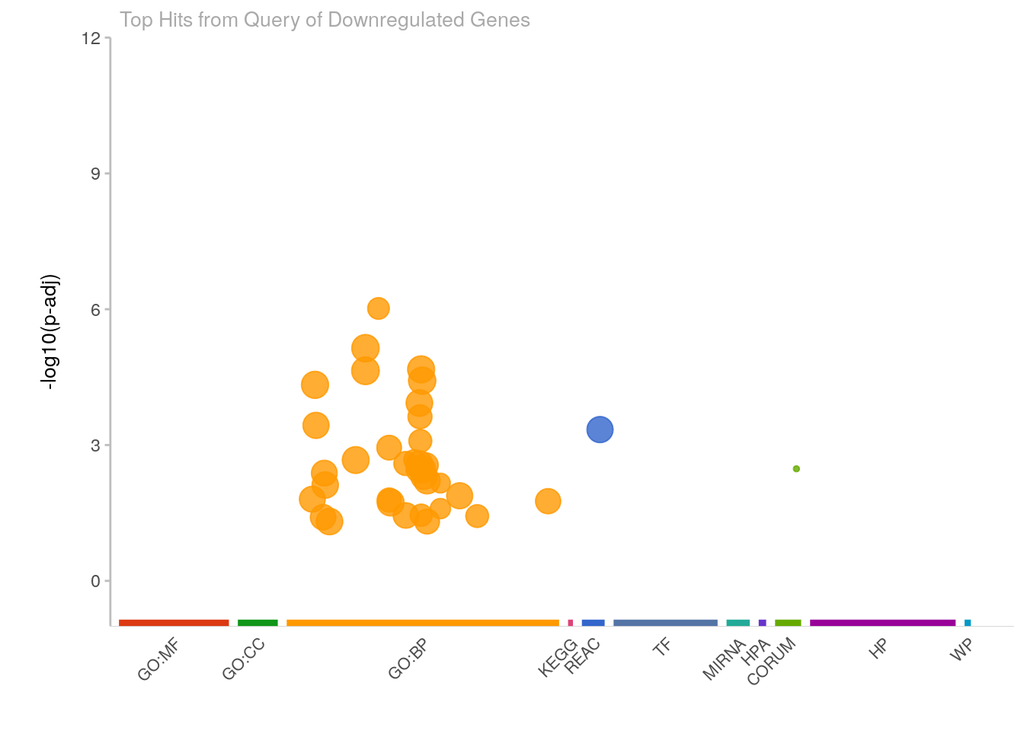

```r
gostplot(atm_gost_down, capped = FALSE, interactive = FALSE)
```

For each query, one gene list was returned with terms from 11 databases. The GLEA performed for the entire list of top hits generated a plot that was the upregulated and downregulated genes put together. Plotting the upregulated and downregulated sets of genes separately simply parsed the whole set of genes into one that had positive logFC values and one that had negative logFC values. They all maintained the same background of all annotated genes. Most of the results were in the GO:BP annotation database for both sets of genes and TF for upregulated genes.